# Biostat 200C Homework 1

Due Apr 11 @ 11:59PM

Published

April 11, 2025

To submit homework, please submit Rmd and html files to bruinlearn by the deadline.

```r
library(tidyverse)
library(GGally)
library(corrplot)
library(gtsummary)
library(knitr)
library(faraway)
library(gridExtra)
library(ggstatsplot)
library(MASS)
library(broom)
library(ggfortify)
```

## 1 Q1. Reivew of linear models (60pts)

The swiss data — use Fertility as the response to practice

### 1.1 Q1.1

An initial data analysis that explores the numerical and graphical characteristics of the data.(5pts)

**Solution:**

```r
data("swiss")
str(swiss)
```

```
'data.frame':   47 obs. of  6 variables:
 $ Fertility       : num  80.2 83.1 92.5 85.8 76.9 76.1 83.8 92.4 82.4 82.9 ...
 $ Agriculture     : num  17 45.1 39.7 36.5 43.5 35.3 70.2 67.8 53.3 45.2 ...
 $ Examination     : int  15 6 5 12 17 9 16 14 12 16 ...
 $ Education       : int  12 9 5 7 15 7 7 8 7 13 ...
 $ Catholic        : num  9.96 84.84 93.4 33.77 5.16 ...
 $ Infant.Mortality: num  22.2 22.2 20.2 20.3 20.6 26.6 23.6 24.9 21 24.4 ...
```

```r
# Summary statistics
summary(swiss)
```

```
   Fertility      Agriculture     Examination      Education
 Min.   :35.00   Min.   : 1.20   Min.   : 3.00   Min.   : 1.00
 1st Qu.:64.70   1st Qu.:35.90   1st Qu.:12.00   1st Qu.: 6.00
 Median :70.40   Median :54.10   Median :16.00   Median : 8.00
 Mean   :70.14   Mean   :50.66   Mean   :16.49   Mean   :10.98
 3rd Qu.:78.45   3rd Qu.:67.65   3rd Qu.:22.00   3rd Qu.:12.00
 Max.   :92.50   Max.   :89.70   Max.   :37.00   Max.   :53.00
    Catholic       Infant.Mortality
 Min.   :  2.150   Min.   :10.80
 1st Qu.:  5.195   1st Qu.:18.15
 Median : 15.140   Median :20.00
 Mean   : 41.144   Mean   :19.94
 3rd Qu.: 93.125   3rd Qu.:21.70
 Max.   :100.000   Max.   :26.60
```

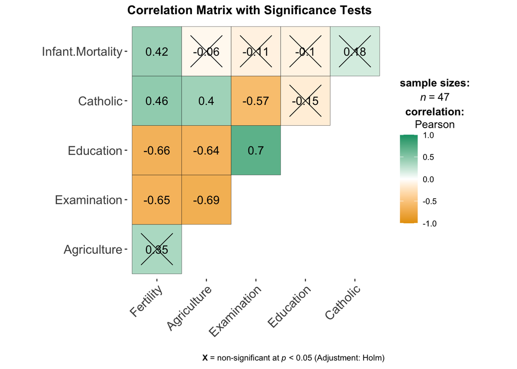

```r
# Correlation matrix
ggcorrmat(
  data = swiss,
  cor.vars = colnames(swiss),
  title = "Correlation Matrix with Significance Tests"
)
```

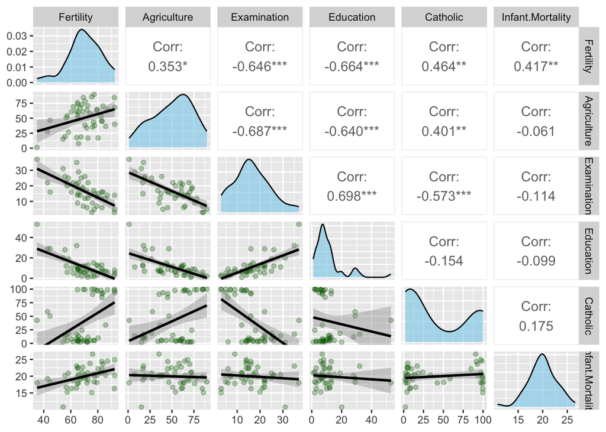

```r
# Pairwise plots
ggpairs(
  swiss,
  lower = list(continuous = wrap("smooth", alpha = 0.3, color = "darkgreen")),
  diag = list(continuous = wrap("densityDiag", fill = "skyblue", alpha = 0.6)),
  upper = list(continuous = wrap("cor", size = 4))
)
```

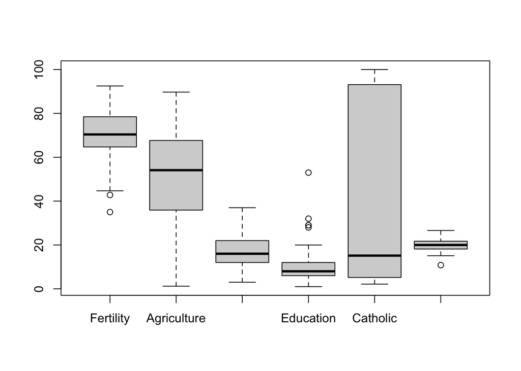

```r
# Boxplot for Fertility
boxplot(swiss)
```

### 1.2 Q1.2

Variable selection to choose the best model. (10pts) **Solution:**

```r
# Full linear model
full_model <- lm(Fertility ~ ., data = swiss)

summary(full_model)
```

```
Call:
lm(formula = Fertility ~ ., data = swiss)

Residuals:
     Min       1Q   Median       3Q      Max
-15.2743  -5.2617   0.5032   4.1198  15.3213

Coefficients:
                 Estimate Std. Error t value Pr(>|t|)
(Intercept)      66.91518   10.70604   6.250 1.91e-07 ***
Agriculture      -0.17211    0.07030  -2.448  0.01873 *
Examination      -0.25801    0.25388  -1.016  0.31546
Education        -0.87094    0.18303  -4.758 2.43e-05 ***
Catholic          0.10412    0.03526   2.953  0.00519 **
Infant.Mortality  1.07705    0.38172   2.822  0.00734 **
---
Signif. codes:  0 '***' 0.001 '**' 0.01 '*' 0.05 '.' 0.1 ' ' 1

Residual standard error: 7.165 on 41 degrees of freedom
Multiple R-squared:  0.7067,    Adjusted R-squared:  0.671
F-statistic: 19.76 on 5 and 41 DF,  p-value: 5.594e-10
```

```r
# Perform stepwise AIC-based selection
step_model <- step(full_model, direction = "both", trace = TRUE)
```

```
Start:  AIC=190.69
Fertility ~ Agriculture + Examination + Education + Catholic +
    Infant.Mortality

                   Df Sum of Sq    RSS    AIC
- Examination       1     53.03 2158.1 189.86
<none>                          2105.0 190.69
- Agriculture       1    307.72 2412.8 195.10
- Infant.Mortality  1    408.75 2513.8 197.03
- Catholic          1    447.71 2552.8 197.75
- Education         1   1162.56 3267.6 209.36

Step:  AIC=189.86
Fertility ~ Agriculture + Education + Catholic + Infant.Mortality

                   Df Sum of Sq    RSS    AIC
<none>                          2158.1 189.86
+ Examination       1     53.03 2105.0 190.69
- Agriculture       1    264.18 2422.2 193.29
- Infant.Mortality  1    409.81 2567.9 196.03
- Catholic          1    956.57 3114.6 205.10
- Education         1   2249.97 4408.0 221.43
```

```r
# Summary of the final selected model
summary(step_model)
```

```
Call:
lm(formula = Fertility ~ Agriculture + Education + Catholic +
    Infant.Mortality, data = swiss)

Residuals:
     Min       1Q   Median       3Q      Max
-14.6765  -6.0522   0.7514   3.1664  16.1422

Coefficients:
                 Estimate Std. Error t value Pr(>|t|)
(Intercept)      62.10131    9.60489   6.466 8.49e-08 ***
Agriculture      -0.15462    0.06819  -2.267  0.02857 *
Education        -0.98026    0.14814  -6.617 5.14e-08 ***
Catholic          0.12467    0.02889   4.315 9.50e-05 ***
Infant.Mortality  1.07844    0.38187   2.824  0.00722 **
---
Signif. codes:  0 '***' 0.001 '**' 0.01 '*' 0.05 '.' 0.1 ' ' 1

Residual standard error: 7.168 on 42 degrees of freedom
Multiple R-squared:  0.6993,    Adjusted R-squared:  0.6707
F-statistic: 24.42 on 4 and 42 DF,  p-value: 1.717e-10
```

```r
# Check the significance of each variable in the selected model
drop1(step_model, test = "F")
```

```
Single term deletions

Model:
Fertility ~ Agriculture + Education + Catholic + Infant.Mortality
                 Df Sum of Sq    RSS    AIC F value    Pr(>F)
<none>                        2158.1 189.86
Agriculture       1    264.18 2422.2 193.29  5.1413   0.02857 *
Education         1   2249.97 4408.0 221.43 43.7886 5.140e-08 ***
Catholic          1    956.57 3114.6 205.10 18.6165 9.503e-05 ***
Infant.Mortality  1    409.81 2567.9 196.03  7.9757   0.00722 **
---
Signif. codes:  0 '***' 0.001 '**' 0.01 '*' 0.05 '.' 0.1 ' ' 1
```

Final model: Fertility ~ Agriculture + Education + Catholic + Infant.Mortality

### 1.3 Q1.3

An exploration of transformations to improve the fit of the model. (10pts) **Solution:**

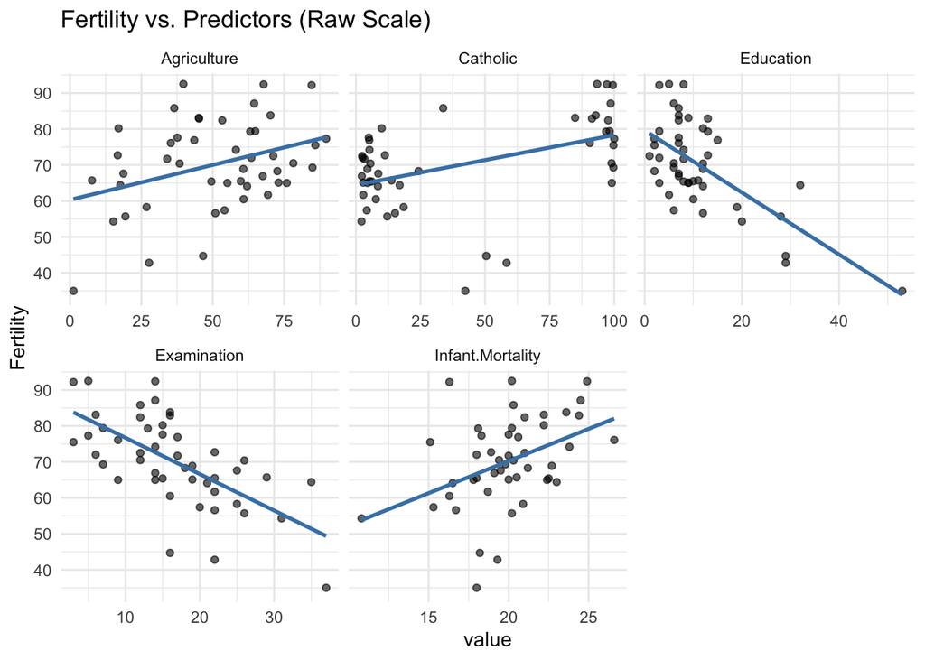

```r
# Check for linearity
swiss %>%
  pivot_longer(cols = -Fertility) %>%
  ggplot(aes(x = value, y = Fertility)) +
  geom_point(alpha = 0.6) +
  geom_smooth(method = "lm", se = FALSE, color = "steelblue") +
  facet_wrap(~ name, scales = "free_x") +
  theme_minimal() +
  labs(title = "Fertility vs. Predictors (Raw Scale)")
```

```r
# Add transformed variable
swiss_trans <- swiss %>%
  mutate(log_Catholic = log(Catholic + 1))


# Fit model with log-transformed Catholic
model_trans <- lm(Fertility ~ Agriculture + Education + log_Catholic +
                    Infant.Mortality, data = swiss_trans)

# Compare with previous model
AIC(step_model, model_trans)
```

```
            df      AIC
step_model   6 325.2408
model_trans  6 328.7104
```

```r
summary(model_trans)
```

```
Call:
lm(formula = Fertility ~ Agriculture + Education + log_Catholic +
    Infant.Mortality, data = swiss_trans)

Residuals:
    Min      1Q  Median      3Q     Max
-14.731  -7.046   1.691   3.482  16.425

Coefficients:
                 Estimate Std. Error t value Pr(>|t|)
(Intercept)      55.46952    9.67771   5.732 9.65e-07 ***
Agriculture      -0.11914    0.06824  -1.746 0.088118 .
Education        -1.01591    0.15657  -6.489 7.87e-08 ***
log_Catholic      3.46384    0.91589   3.782 0.000486 ***
Infant.Mortality  1.07149    0.39935   2.683 0.010389 *
---
Signif. codes:  0 '***' 0.001 '**' 0.01 '*' 0.05 '.' 0.1 ' ' 1

Residual standard error: 7.438 on 42 degrees of freedom
Multiple R-squared:  0.6763,    Adjusted R-squared:  0.6455
F-statistic: 21.94 on 4 and 42 DF,  p-value: 7.844e-10
```

```r
# plot termplots side by side
par(mfrow=c(2,2))
termplot(step_model, partial.resid = TRUE, terms = 3)
termplot(model_trans, partial.resid = TRUE, terms = 3)

# polynomial transformation for Catholic
model_poly <- lm(Fertility ~ Agriculture + poly(Catholic, 2) + I(Education^2) +
                   Infant.Mortality, data = swiss)
AIC(step_model, model_poly)
```

[output not shown]

```r
# square root transformation for Catholic
model_sqrt <- lm(Fertility ~ Agriculture + sqrt(Catholic) + Education +
                   Infant.Mortality, data = swiss)
AIC(step_model, model_sqrt)
```

```
           df      AIC
step_model  6 325.2408
model_sqrt  6 326.7696
```

[output not shown]

[figure not shown]

```r
# inverse for Catholic
model_inv <- lm(Fertility ~ Agriculture + I(1 / (Catholic + 1)) + Education +
                  Infant.Mortality, data = swiss)
AIC(step_model, model_inv)
```

The original model (without transformation) has the lowest AIC, meaning it fits the data better despite the skew in the Catholic variable.

### 1.4 Q1.4

Diagnostics to check the assumptions of your model. (10pts) **Solution:**

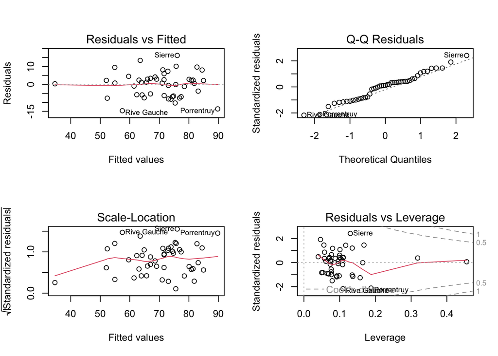

```r
final_model <- step_model

par(mfrow = c(2, 2))
plot(final_model)
```

```r
# Reset graphic parameters
par(mfrow = c(1, 1))
```

The residuals show no major nonlinear patterns or heteroscedasticity issues. The QQ plot indicates that the residuals are approximately normally distributed, and the scale-location plot shows a random scatter of points, indicating homoscedasticity. No highly influential points are present based on leverage and Cook’s distance. The model appears to be a relatively good fit for the data based on these diagnostics.

### 1.5 Q1.5

Some predictions of future observations for interesting values of the predictors.(5pts) **Solution:**

```r
# Quantile values for predictors
catholic_vals <- quantile(swiss$Catholic, c(0.25, 0.75))
edu_vals <- quantile(swiss$Education, c(0.25, 0.75))

# Create prediction grid
pred_df <- tibble(
  Catholic = rep(catholic_vals, each = 2),
  Education = rep(edu_vals, times = 2),
  Agriculture = mean(swiss$Agriculture),
  Infant.Mortality = mean(swiss$Infant.Mortality)
)

# Generate predictions + 95% prediction intervals
pred_output <- predict(final_model, newdata = pred_df, interval = "prediction")

# Combine with input
pred_results <- bind_cols(pred_df, as_tibble(pred_output))

# View results
pred_results
```

```
# A tibble: 4 × 7
  Catholic Education Agriculture Infant.Mortality   fit   lwr   upr
     <dbl>     <dbl>       <dbl>            <dbl> <dbl> <dbl> <dbl>
1     5.20         6        50.7             19.9  70.5  55.7  85.3
2     5.20        12        50.7             19.9  64.7  49.9  79.4
3    93.1          6        50.7             19.9  81.5  66.4  96.6
4    93.1         12        50.7             19.9  75.6  60.7  90.5
```

```r
xtabs(round(fit, 1) ~ Education + Catholic, data = pred_results)
```

```
         Catholic
Education 5.195 93.125
       6   70.5   81.5
       12  64.7   75.6
```

Fertility for the 25th percentile of Catholic and 25th percentile of Education is 70.5, while for the 75th percentile of Catholic and 75th percentile of Education is 75.6 and for the 25th percentile of Catholic and 75th percentile of Education is 64.7. This indicates that lower education and stronger Catholic values are associated with increased fertility rates.

### 1.6 Q1.6

An interpretation of the meaning of the model by writing a scientific abstract. (<150 words) (10pts)

- BACKGROUND: Fertility rates across regions in Switzerland have historically been influenced by socio-cultural and economic factors. Prior studies suggest that religious affiliation and education may play significant roles in shaping demographic patterns.
- OBJECTIVE: To model fertility levels in Swiss provinces using socioeconomic predictors and evaluate their relative influence.
- METHODS: We analyzed the built-in swiss dataset, using fertility as the outcome variable. A multiple linear regression model was constructed with predictors including Agriculture, Education, Catholic affiliation, and Infant Mortality. Stepwise AIC was used for variable selection, and model diagnostics were performed to verify assumptions.
- RESULTS: The final model revealed that higher Catholic affiliation and lower education levels were significantly associated with higher fertility rates. Model assumptions were reasonably satisfied. Predictions across realistic covariate values reflected these relationships
- CONCLUSIONS: Fertility in Swiss regions is strongly associated with cultural and educational factors. These results underscore the demographic impact of religion and education in shaping fertility patterns. Further research is needed to explore the underlying mechanisms and implications for public policy.

## 2 Q2.(70pts)

The National Institute of Diabetes and Digestive and Kidney Diseases conducted a study on 768 adult female Pima Indians living near Phoenix. The purpose of the study was to investigate factors related to diabetes. The data may be found in the the dataset `pima`.

### 2.1 Q2.1

Create a factor version of the test results and use this to produce an interleaved histogram to show how the distribution of insulin differs between those testing positive and negative. Do you notice anything unbelievable about the plot? (5pts) **Solution:**

```r
data(pima)
str(pima)
```

```
'data.frame':   768 obs. of  9 variables:
 $ pregnant : int  6 1 8 1 0 5 3 10 2 8 ...
 $ glucose  : int  148 85 183 89 137 116 78 115 197 125 ...
 $ diastolic: int  72 66 64 66 40 74 50 0 70 96 ...
 $ triceps  : int  35 29 0 23 35 0 32 0 45 0 ...
 $ insulin  : int  0 0 0 94 168 0 88 0 543 0 ...
 $ bmi      : num  33.6 26.6 23.3 28.1 43.1 25.6 31 35.3 30.5 0 ...
 $ diabetes : num  0.627 0.351 0.672 0.167 2.288 ...
 $ age      : int  50 31 32 21 33 30 26 29 53 54 ...
 $ test     : int  1 0 1 0 1 0 1 0 1 1 ...
```

```r
summary(pima)
```

```
    pregnant         glucose        diastolic         triceps
 Min.   : 0.000   Min.   :  0.0   Min.   :  0.00   Min.   : 0.00
 1st Qu.: 1.000   1st Qu.: 99.0   1st Qu.: 62.00   1st Qu.: 0.00
 Median : 3.000   Median :117.0   Median : 72.00   Median :23.00
 Mean   : 3.845   Mean   :120.9   Mean   : 69.11   Mean   :20.54
 3rd Qu.: 6.000   3rd Qu.:140.2   3rd Qu.: 80.00   3rd Qu.:32.00
 Max.   :17.000   Max.   :199.0   Max.   :122.00   Max.   :99.00
    insulin           bmi           diabetes           age
 Min.   :  0.0   Min.   : 0.00   Min.   :0.0780   Min.   :21.00
 1st Qu.:  0.0   1st Qu.:27.30   1st Qu.:0.2437   1st Qu.:24.00
 Median : 30.5   Median :32.00   Median :0.3725   Median :29.00
 Mean   : 79.8   Mean   :31.99   Mean   :0.4719   Mean   :33.24
 3rd Qu.:127.2   3rd Qu.:36.60   3rd Qu.:0.6262   3rd Qu.:41.00
 Max.   :846.0   Max.   :67.10   Max.   :2.4200   Max.   :81.00
      test
 Min.   :0.000
 1st Qu.:0.000
 Median :0.000
 Mean   :0.349
 3rd Qu.:1.000
 Max.   :1.000
```

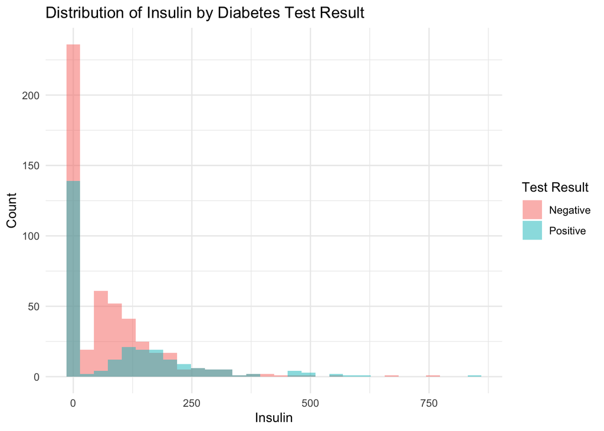

```r
# Convert `test` to a factor
pima <- pima %>%
  mutate(test_factor = factor(test, labels = c("Negative", "Positive")))

# Interleaved histogram
ggplot(pima, aes(x = insulin, fill = test_factor)) +
  geom_histogram(position = "identity", alpha = 0.5, bins = 30) +
  labs(
    title = "Distribution of Insulin by Diabetes Test Result",
    x = "Insulin",
    y = "Count",
    fill = "Test Result"
  ) +
  theme_minimal()
```

The histogram reveals that a large number of individuals, both diabetic and non-diabetic, have insulin values recorded as 0. This is highly unlikely in real biological measurements, indicating that these values likely represent missing data.

### 2.2 Q2.2

Replace the zero values of `insulin` with the missing value code `NA`. Recreatethe interleaved histogram plot and comment on the distribution. (5pts) **Solution:**

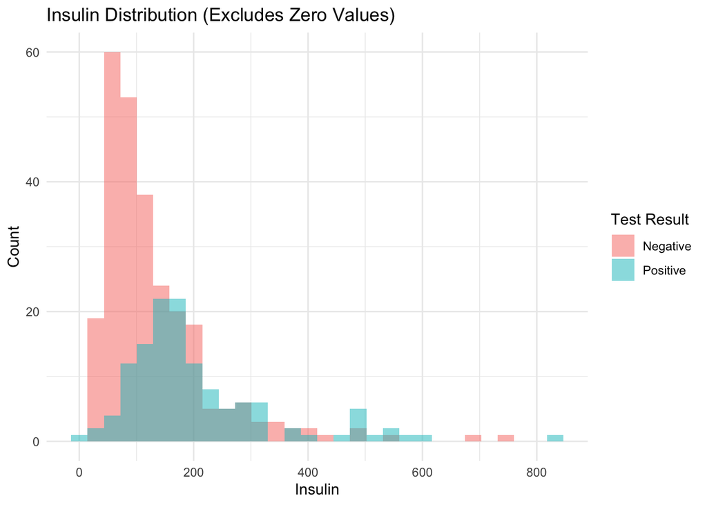

```r
# insulin = 0 as NA
pima <- pima %>%
  mutate(insulin_na = ifelse(insulin == 0, NA, insulin))

# Plot histogram using the new variable
ggplot(pima, aes(x = insulin_na, fill = test_factor)) +
  geom_histogram(position = "identity", alpha = 0.5, bins = 30) +
  labs(
    title = "Insulin Distribution (Excludes Zero Values)",
    x = "Insulin",
    y = "Count",
    fill = "Test Result"
  ) +
  theme_minimal()
```

The spike at zero has been eliminated, revealing that individuals who tested positive for diabetes tend to have higher and more variable insulin levels. Positive test group shows a broader and more right-skewed distribution. Negative group is tightly clustered at lower insulin values.

### 2.3 Q2.3

Replace the incredible zeroes in other variables with the missing value code. Fit a model with the result of the diabetes test as the response and all the other variables as predictors. How many observations were used in the model fitting? Why is this less than the number of observations in the data frame. (10pts) **Solution:**

```r
# New dataset with NA-coded vars
pima_clean <- pima %>%
  mutate(
    glucose = na_if(glucose, 0),
    diastolic = na_if(diastolic, 0),
    triceps = na_if(triceps, 0),
    insulin = na_if(insulin, 0),
    bmi = na_if(bmi, 0)
  )

# Fit logistic regression with all predictors
glm_full <- glm(test ~ pregnant + glucose + diastolic + triceps +
                  insulin + bmi + diabetes + age,
                data = pima_clean,
                family = binomial())

summary(glm_full)
```

```
Call:
glm(formula = test ~ pregnant + glucose + diastolic + triceps +
    insulin + bmi + diabetes + age, family = binomial(), data = pima_clean)

Coefficients:
              Estimate Std. Error z value Pr(>|z|)
(Intercept) -1.004e+01  1.218e+00  -8.246  < 2e-16 ***
pregnant     8.216e-02  5.543e-02   1.482  0.13825
glucose      3.827e-02  5.768e-03   6.635 3.24e-11 ***
diastolic   -1.420e-03  1.183e-02  -0.120  0.90446
triceps      1.122e-02  1.708e-02   0.657  0.51128
insulin     -8.253e-04  1.306e-03  -0.632  0.52757
bmi          7.054e-02  2.734e-02   2.580  0.00989 **
diabetes     1.141e+00  4.274e-01   2.669  0.00760 **
age          3.395e-02  1.838e-02   1.847  0.06474 .
---
Signif. codes:  0 '***' 0.001 '**' 0.01 '*' 0.05 '.' 0.1 ' ' 1

(Dispersion parameter for binomial family taken to be 1)

    Null deviance: 498.10  on 391  degrees of freedom
Residual deviance: 344.02  on 383  degrees of freedom
  (376 observations deleted due to missingness)
AIC: 362.02

Number of Fisher Scoring iterations: 5
```

```r
# Number of observations used in the model fitting
nrow(glm_full$model)
```

```
[1] 392
```

The number of observations used in the model is fewer than the original dataset because rows with any missing values in the predictors are automatically dropped (glm() uses na.omit() by default). Since multiple variables had zeroes coded as missing, this reduced the usable sample size. The model identified glucose, BMI, and diabetes pedigree as significant predictors of diabetes test results.

### 2.4 Q2.4

Refit the model but now without the insulin and triceps predictors. How many observations were used in fitting this model? Devise a test to compare this model with that in the previous question. (10pts) **Solution:**

```r
# Get the row indices used in glm_full
used_rows <- as.numeric(rownames(glm_full$model))

# Refit reduced model
glm_reduced <- glm(test ~ pregnant + glucose + diastolic + bmi + diabetes + age,
                   data = pima_clean[used_rows, ],
                   family = binomial())
summary(glm_reduced)
```

```
Call:
glm(formula = test ~ pregnant + glucose + diastolic + bmi + diabetes +
    age, family = binomial(), data = pima_clean[used_rows, ])

Coefficients:
              Estimate Std. Error z value Pr(>|z|)
(Intercept) -9.9604796  1.1818764  -8.428  < 2e-16 ***
pregnant     0.0840497  0.0550728   1.526 0.126971
glucose      0.0364863  0.0049973   7.301 2.85e-13 ***
diastolic   -0.0008002  0.0118034  -0.068 0.945949
bmi          0.0785728  0.0215674   3.643 0.000269 ***
diabetes     1.1492368  0.4250340   2.704 0.006854 **
age          0.0346079  0.0181919   1.902 0.057121 .
---
Signif. codes:  0 '***' 0.001 '**' 0.01 '*' 0.05 '.' 0.1 ' ' 1

(Dispersion parameter for binomial family taken to be 1)

    Null deviance: 498.10  on 391  degrees of freedom
Residual deviance: 344.88  on 385  degrees of freedom
AIC: 358.88

Number of Fisher Scoring iterations: 5
```

```r
# Number of observations used
nrow(glm_reduced$model)
```

```
[1] 392
```

```r
# Compare full vs. reduced model using LRT
anova(glm_reduced, glm_full, test = "Chisq")
```

```
Analysis of Deviance Table

Model 1: test ~ pregnant + glucose + diastolic + bmi + diabetes + age
Model 2: test ~ pregnant + glucose + diastolic + triceps + insulin + bmi +
    diabetes + age
  Resid. Df Resid. Dev Df Deviance Pr(>Chi)
1       385     344.88
2       383     344.02  2  0.85931   0.6507
```

To compare the full and reduced models, I specified the same rows used in the full model when fitting the reduced one. This was necessary because the likelihood ratio test (anova()) requires both models to be fit on the exact same data.  
The likelihood ratio test gave a p-value of 0.6507, indicating that dropping insulin and triceps did not significantly worsen the model. Therefore, the reduced model is preferred for being simpler with no loss in predictive power.

**Alternative solution (not forrcing the same used rows onto the reduced model):**

```r
glm_reduced_2 <- glm(test ~ pregnant + glucose + diastolic + bmi + diabetes +
                       age,
                   data = pima_clean,
                   family = binomial())

summary(glm_reduced_2)
```

```
Call:
glm(formula = test ~ pregnant + glucose + diastolic + bmi + diabetes +
    age, family = binomial(), data = pima_clean)

Coefficients:
             Estimate Std. Error z value Pr(>|z|)
(Intercept) -8.962146   0.820892 -10.918  < 2e-16 ***
pregnant     0.117863   0.033418   3.527  0.00042 ***
glucose      0.035194   0.003605   9.763  < 2e-16 ***
diastolic   -0.008916   0.008618  -1.035  0.30084
bmi          0.090926   0.015740   5.777 7.61e-09 ***
diabetes     0.960515   0.306415   3.135  0.00172 **
age          0.016944   0.009834   1.723  0.08489 .
---
Signif. codes:  0 '***' 0.001 '**' 0.01 '*' 0.05 '.' 0.1 ' ' 1

(Dispersion parameter for binomial family taken to be 1)

    Null deviance: 931.94  on 723  degrees of freedom
Residual deviance: 672.86  on 717  degrees of freedom
  (44 observations deleted due to missingness)
AIC: 686.86

Number of Fisher Scoring iterations: 5
```

```r
# Number of observations used
nrow(glm_reduced_2$model)
```

```
[1] 724
```

```r
# Compare the models via AIC
AIC(glm_full, glm_reduced)
```

```
            df      AIC
glm_full     9 362.0212
glm_reduced  7 358.8805
```

The AIC of the reduced model is lower than that of the full model, indicating a better fit.

### 2.5 Q2.5

Use AIC to select a model. You will need to take account of the missing values. Which predictors are selected? How many cases are used in your selected model? (10pts) **Solution:**

```r
# rows actually used by glm_full
data_used <- glm_full$model

# Refit full model using only complete cases to lock in the data
glm_start <- glm(test ~ pregnant + glucose + diastolic + triceps +
                   insulin + bmi + diabetes + age,
                 data = data_used,
                 family = binomial())

# Run AIC stepwise selection with fixed dataset
model_aic <- step(glm_start, direction = "both", trace = TRUE)
```

```
Start:  AIC=362.02
test ~ pregnant + glucose + diastolic + triceps + insulin + bmi +
    diabetes + age

            Df Deviance    AIC
- diastolic  1   344.04 360.04
- insulin    1   344.42 360.42
- triceps    1   344.45 360.45
<none>           344.02 362.02
- pregnant   1   346.24 362.24
- age        1   347.55 363.55
- bmi        1   350.89 366.89
- diabetes   1   351.58 367.58
- glucose    1   396.95 412.95

Step:  AIC=360.04
test ~ pregnant + glucose + triceps + insulin + bmi + diabetes +
    age

            Df Deviance    AIC
- insulin    1   344.42 358.42
- triceps    1   344.46 358.46
<none>           344.04 360.04
- pregnant   1   346.24 360.24
- age        1   347.60 361.60
+ diastolic  1   344.02 362.02
- bmi        1   351.28 365.28
- diabetes   1   351.67 365.67
- glucose    1   397.31 411.31

Step:  AIC=358.42
test ~ pregnant + glucose + triceps + bmi + diabetes + age

            Df Deviance    AIC
- triceps    1   344.89 356.89
<none>           344.42 358.42
- pregnant   1   346.74 358.74
- age        1   347.87 359.87
+ insulin    1   344.04 360.04
+ diastolic  1   344.42 360.42
- bmi        1   351.32 363.32
- diabetes   1   351.90 363.90
- glucose    1   411.11 423.11

Step:  AIC=356.89
test ~ pregnant + glucose + bmi + diabetes + age

            Df Deviance    AIC
<none>           344.89 356.89
- pregnant   1   347.23 357.23
+ triceps    1   344.42 358.42
+ insulin    1   344.46 358.46
- age        1   348.72 358.72
+ diastolic  1   344.88 358.88
- diabetes   1   352.72 362.72
- bmi        1   360.44 370.44
- glucose    1   411.85 421.85
```

```r
summary(model_aic)
```

```
Call:
glm(formula = test ~ pregnant + glucose + bmi + diabetes + age,
    family = binomial(), data = data_used)

Coefficients:
             Estimate Std. Error z value Pr(>|z|)
(Intercept) -9.992080   1.086866  -9.193  < 2e-16 ***
pregnant     0.083953   0.055031   1.526 0.127117
glucose      0.036458   0.004978   7.324 2.41e-13 ***
bmi          0.078139   0.020605   3.792 0.000149 ***
diabetes     1.150913   0.424242   2.713 0.006670 **
age          0.034360   0.017810   1.929 0.053692 .
---
Signif. codes:  0 '***' 0.001 '**' 0.01 '*' 0.05 '.' 0.1 ' ' 1

(Dispersion parameter for binomial family taken to be 1)

    Null deviance: 498.10  on 391  degrees of freedom
Residual deviance: 344.89  on 386  degrees of freedom
AIC: 356.89

Number of Fisher Scoring iterations: 5
```

```r
# Number of observations used
nrow(model_aic$model)
```

```
[1] 392
```